# hw02_ggplot2_dplyr

Xuemeng Li

27/09/2019

# Objective

The goal is to get feet wet with ggplot2 and dplyr to explore a dataset.

```r
library(gapminder)
library(tidyverse)
```

# Exercise 1: Basic dplyr

##1.1 Use filter() to subset the gapminder data to three countries of your choice in the 1970’s.

```r
gapminder %>%
  filter (country == "China" | country == "Canada" | country == "Austria") %>%
  filter (year >= 1970 & year <1980)
```

```
## # A tibble: 6 x 6
##   country continent  year lifeExp       pop gdpPercap
##   <fct>   <fct>     <int>   <dbl>     <int>     <dbl>
## 1 Austria Europe     1972    70.6   7544201    16662.
## 2 Austria Europe     1977    72.2   7568430    19749.
## 3 Canada  Americas   1972    72.9  22284500    18971.
## 4 Canada  Americas   1977    74.2  23796400    22091.
## 5 China   Asia       1972    63.1 862030000      677.
## 6 China   Asia       1977    64.0 943455000      741.
```

##1.2 Use the pipe operator %>% to select “country” and “gdpPercap” from your filtered dataset in 1.1.

```r
gapminder %>%
  filter (country == "China" | country == "Canada" | country == "Austria") %>%
  filter (year >= 1970 & year <1980) %>%
  select (country, gdpPercap)
```

```
## # A tibble: 6 x 2
##   country gdpPercap
##   <fct>       <dbl>
## 1 Austria    16662.
## 2 Austria    19749.
## 3 Canada     18971.
## 4 Canada     22091.
## 5 China        677.
## 6 China        741.
```

##1.3 Filter gapminder to all entries that have experienced a drop in life expectancy. Be sure to include a new variable that’s the increase in life expectancy in your tibble. Hint: you might find the lag() or diff() functions useful.

```r
gapminder %>%
  group_by(country) %>%
  arrange(year)%>%
  mutate (inc_life_exp = lifeExp - lag(lifeExp)) %>%
  filter (inc_life_exp < 0) %>%
  DT::datatable()
```

|  | country | continent | year | lifeExp | pop | gdpPercap | inc_life_exp |
| --- | --- | --- | --- | --- | --- | --- | --- |
| 1 | China | Asia | 1962 | 44.50136 | 665770000 | 487.6740183 | -6.0476 |
| 2 | Cambodia | Asia | 1972 | 40.317 | 7450606 | 421.6240257 | -5.098 |
| 3 | Czech Republic | Europe | 1972 | 70.29 | 9862158 | 13108.4536 | -0.0899999999999892 |
| 4 | Netherlands | Europe | 1972 | 73.75 | 13329874 | 18794.74567 | -0.0699999999999932 |
| 5 | Slovak Republic | Europe | 1972 | 70.35 | 4593433 | 9674.167626 | -0.63000000000001 |
| 6 | Bulgaria | Europe | 1977 | 70.81 | 8797022 | 7612.240438 | -0.0900000000000034 |
| 7 | Cambodia | Asia | 1977 | 31.22 | 6978607 | 524.9721832 | -9.097 |
| 8 | El Salvador | Americas | 1977 | 56.696 | 4282586 | 5138.922374 | -1.511 |
| 9 | Poland | Europe | 1977 | 70.67 | 34621254 | 9508.141454 | -0.179999999999993 |
| 10 | Uganda | Africa | 1977 | 50.35 | 11457758 | 843.7331372 | -0.665999999999997 |

[output cut: 92 more lines]

##1.4 Filter gapminder so that it shows the max GDP per capita experienced by each country. Hint: you might find the max() function useful here.

```r
gapminder %>%
  select (country, year, gdpPercap) %>%
  group_by(country) %>%
  mutate (max_gdpPercap = max(gdpPercap)) %>%
  filter (max_gdpPercap == gdpPercap) %>%
  DT::datatable()
```

|  | country | year | gdpPercap | max_gdpPercap |
| --- | --- | --- | --- | --- |
| 1 | Afghanistan | 1982 | 978.0114388 | 978.0114388 |
| 2 | Albania | 2007 | 5937.029526 | 5937.029526 |
| 3 | Algeria | 2007 | 6223.367465 | 6223.367465 |
| 4 | Angola | 1967 | 5522.776375 | 5522.776375 |
| 5 | Argentina | 2007 | 12779.37964 | 12779.37964 |
| 6 | Australia | 2007 | 34435.36744 | 34435.36744 |
| 7 | Austria | 2007 | 36126.4927 | 36126.4927 |
| 8 | Bahrain | 2007 | 29796.04834 | 29796.04834 |
| 9 | Bangladesh | 2007 | 1391.253792 | 1391.253792 |
| 10 | Belgium | 2007 | 33692.60508 | 33692.60508 |

[output cut: 132 more lines]

##1.5 Produce a scatterplot of Canada’s life expectancy vs. GDP per capita using ggplot2, without defining a new variable. That is, after filtering the gapminder data set, pipe it directly into the ggplot() function. Ensure GDP per capita is on a log scale.

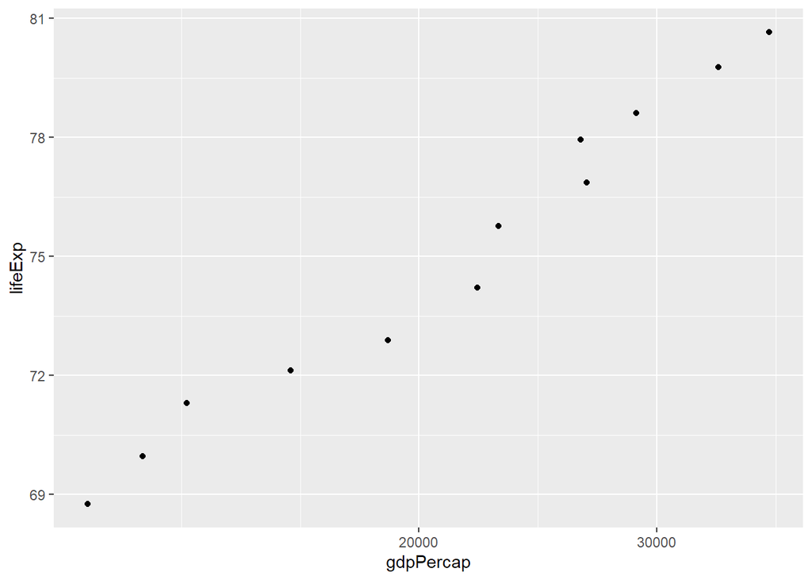

```r
gapminder %>%
  filter (country == "Canada") %>%
  ggplot (aes(gdpPercap, lifeExp)) +
  geom_point () +
  scale_x_log10()
```

# Exercise 2: Explore individual variables with dplyr

## 2.1 Possible values/ranges of each variable

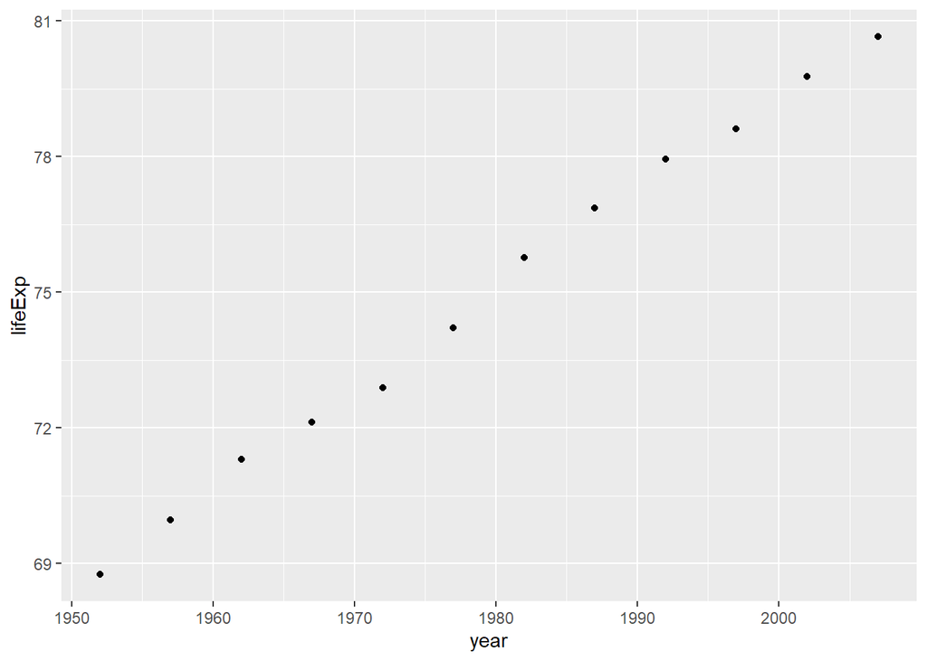

```r
gapminder %>%
  filter (country == "Canada") %>%
  ggplot(aes(year, lifeExp)) +
  geom_point ()
```

## 2.2 Tailor to the variable at hand

1. Canada’s life expense

```r
gapminder %>%
  filter (country == "Canada") %>%
  summarise("min_lifeExp" = min(lifeExp), "mean_lifeExp" = mean(lifeExp), "max_lifeExp" = max(lifeExp))
```

```
## # A tibble: 1 x 3
##   min_lifeExp mean_lifeExp max_lifeExp
##         <dbl>        <dbl>       <dbl>
## 1        68.8         74.9        80.7
```

2. Asia’s population

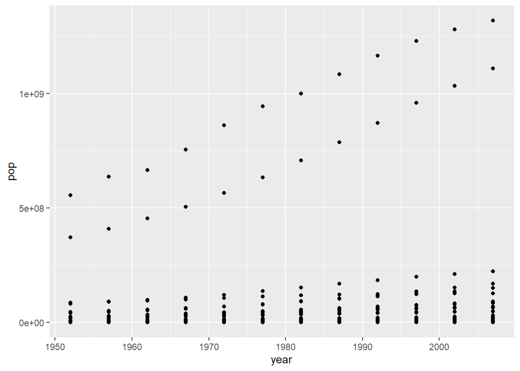

```r
gapminder %>%
  filter (continent == "Asia") %>%
  ggplot (aes(year, pop)) +
  geom_point()
```

# Exercise 3: Explore various plot types

## 3.1 A scatterplot of two quantitative variables.

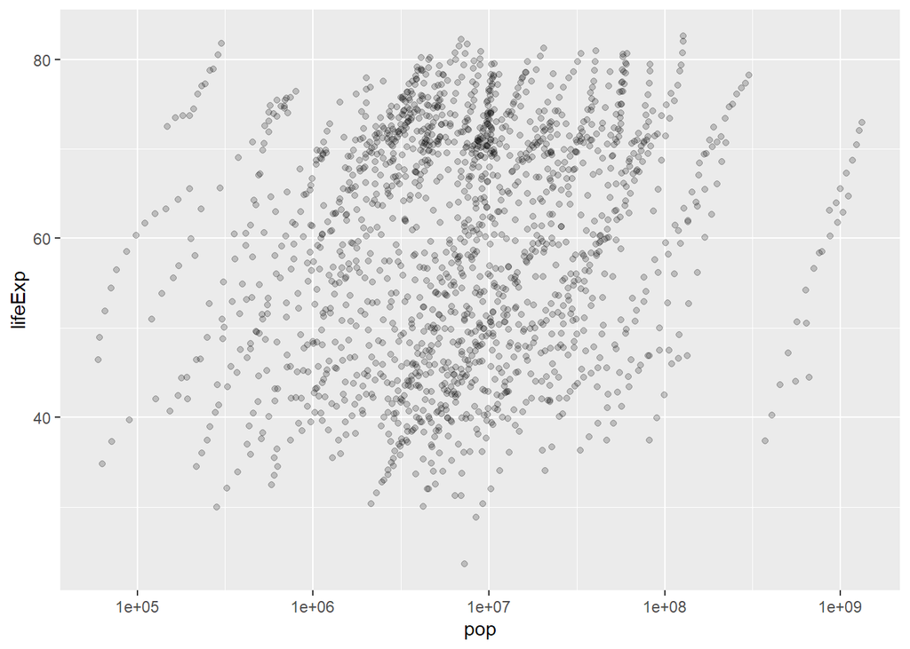

```r
gapminder %>%
  group_by (continent) %>%
  ggplot (aes(pop, lifeExp, continent)) +
  geom_point(alpha = 0.2) +
  scale_x_log10()
```

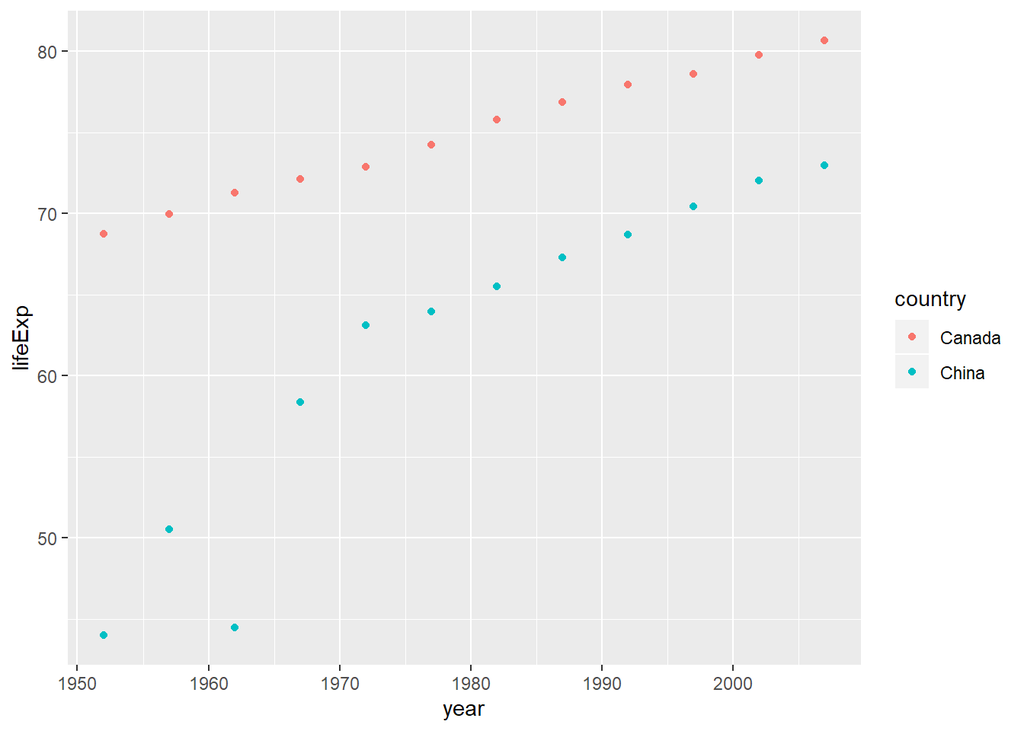

```r
gapminder %>%
  filter (country == "Canada" | country == "China") %>%
  ggplot (aes(x=year, y=lifeExp, col=country)) +
  geom_point()
```

# Recycling

```r
filter(gapminder, country == c("Rwanda", "Afghanistan"))
```

```
## # A tibble: 12 x 6
##    country     continent  year lifeExp      pop gdpPercap
##    <fct>       <fct>     <int>   <dbl>    <int>     <dbl>
##  1 Afghanistan Asia       1957    30.3  9240934      821.
##  2 Afghanistan Asia       1967    34.0 11537966      836.
##  3 Afghanistan Asia       1977    38.4 14880372      786.
##  4 Afghanistan Asia       1987    40.8 13867957      852.
##  5 Afghanistan Asia       1997    41.8 22227415      635.
##  6 Afghanistan Asia       2007    43.8 31889923      975.
##  7 Rwanda      Africa     1952    40    2534927      493.
##  8 Rwanda      Africa     1962    43    3051242      597.
##  9 Rwanda      Africa     1972    44.6  3992121      591.
## 10 Rwanda      Africa     1982    46.2  5507565      882.
## 11 Rwanda      Africa     1992    23.6  7290203      737.
## 12 Rwanda      Africa     2002    43.4  7852401      786.
```

The analyst’s intent was to get the data for Rwanda and Afghanistan. To correct it, an “or” operator should be used

```r
filter(gapminder, country == "Rwanda" | country == "Afghanistan")
```

```
## # A tibble: 24 x 6
##    country     continent  year lifeExp      pop gdpPercap
##    <fct>       <fct>     <int>   <dbl>    <int>     <dbl>
##  1 Afghanistan Asia       1952    28.8  8425333      779.
##  2 Afghanistan Asia       1957    30.3  9240934      821.
##  3 Afghanistan Asia       1962    32.0 10267083      853.
##  4 Afghanistan Asia       1967    34.0 11537966      836.
##  5 Afghanistan Asia       1972    36.1 13079460      740.
##  6 Afghanistan Asia       1977    38.4 14880372      786.
##  7 Afghanistan Asia       1982    39.9 12881816      978.
##  8 Afghanistan Asia       1987    40.8 13867957      852.
##  9 Afghanistan Asia       1992    41.7 16317921      649.
## 10 Afghanistan Asia       1997    41.8 22227415      635.
## # ... with 14 more rows
```